# RNA-seq analysis

Lihui Lin

August 25, 2020

# 1 Introduction

This tutorial provides some basic analysis methods for bulk RNA-seq data:  
1. Data normalization  
2. Clustering analysis  
3. Principle component analysis  
4. Defferential expressed genes analsys  
5. Enrichment analysis  
This tutorial refers to [RNA-seq workflows](http://www.bioconductor.org/packages/release/workflows/vignettes/rnaseqGene/inst/doc/rnaseqGene.html) in `bioconductor`.

Feel free to contact me if you have any question:  
E-mail: lin_lihui@gibh.ac.cn  
WeChart: zasty1888

# 2 Preparation

## 2.1 Software

All the analysis below rely on R environment. Please install the R and relative software before the course.

1. Download and install R: https://mirrors.tuna.tsinghua.edu.cn/CRAN/
- For Windows user, click `Download R for Windows` and select `install R for the first time`.
- For Mac user, click `Download R for (Mac) OS X` and selcet `R-3.5.1.pkg`.
2. Download and install RStudio: https://www.rstudio.com/products/rstudio/download/
3. Install R packages for analysis  
   Open newly installed RStudio, paste and execute the code below in the **Console** panel.

```r
options(useHTTPS=FALSE, BioC_mirror="http://mirrors.tuna.tsinghua.edu.cn/bioconductor/")
options("repos" = c(CRAN="https://mirrors.tuna.tsinghua.edu.cn/CRAN/"))
ipak <- function(pkg, repository = c("CRAN", "Bioconductor", "github")) {
    new.pkg <- pkg[!(pkg %in% installed.packages()[, "Package"])]
    if (length(new.pkg)) {
        if (repository == "CRAN") {
            install.packages(new.pkg)
        }
        if (repository == "Bioconductor") {
          if (!requireNamespace("BiocManager", quietly = TRUE)) {
            install.packages("BiocManager")
          }
          BiocManager::install(new.pkg)
        }
    }
}
```

```r
# CRAN packages
cranpackages <- c("dplyr","ggplot2","matrixStats","pheatmap","DT","data.table")
ipak(cranpackages, repository = "CRAN")
```

```r
# BIOCONDUCTOR packages
biocpackages <- c("DESeq2","genefilter","clusterProfiler","ReactomePA","org.Mm.eg.db","DO.db","GO.db","GenomeInfoDb","enrichplot")
ipak(biocpackages, repository = "Bioconductor")
```

## 2.2 Data

In this tutorials, we provide a data set with 14 samples of Oct4, Sox2, Klf4 induced reprogramming https://charliex210.github.io/docs/Practice.zip. You should download and decompress the file as `Practice`. The cells were sampling in different time point for two replicates. The sequencing result of each sample was aligned to the transcriptome using `RSEM+Bowtie2` in HPC. The alignment results are stored in `Practice/DataSource/mmv86`, you need to merge all samples into one table by executing `Practice/DataSource/MergeData.R`.

# 3 Start

## 3.1 Load packages

The R packages need to be loaded using `library` or `require` before implementing their functions.

```r
library(dplyr)
library(ggplot2)
library(DESeq2)
library(matrixStats)
library(pheatmap)
library(genefilter)
library(clusterProfiler)
library(ReactomePA)
library(enrichplot)
library(DT)
```

## 3.2 Load data

The data is stored in Comma-Separated Values (.csv) format, which can be loaded using `read.csv`. Another common used format is Tab-Separated Values (.tsv), which can be loaded using `read.delim` or `read.table`. In addition, we need to set the gene symbol as `row.names` and the sample id as `col.names`.

```r
# setwd("F:/RNAseq/Practise/DEG") # Set working directory
counts = read.csv("../DataSource/osk_count.csv", row.names = 1, header = TRUE, check.names = FALSE)
```

```r
dim(counts)
```

```
## [1] 32343    14
```

```r
counts[1:5,1:6]
```

```
##       ESC_r1 ESC_r2 MEF_r1 MEF_r2 OSK_D0_r1 OSK_D0_r2
## Gnai3    587    426   1053    415       557       838
## Pbsn       0      0      0      0         0         0
## Cdc45    417    283    156     30       111       125
## H19        8     97  56924   8068      3215      3063
## Scml2     65     31     13      1        19        32
```

```r
colnames(counts)
```

```
##  [1] "ESC_r1"    "ESC_r2"    "MEF_r1"    "MEF_r2"    "OSK_D0_r1" "OSK_D0_r2"
##  [7] "OSK_D1_r1" "OSK_D1_r2" "OSK_D3_r1" "OSK_D3_r2" "OSK_D5_r1" "OSK_D5_r2"
## [13] "OSK_D7_r1" "OSK_D7_r2"
```

## 3.3 Create SummarizedExperiment object

We use [SummarizedExperiment](http://www.bioconductor.org/packages/release/bioc/html/SummarizedExperiment.html) object to organize expression data. The `assay` (pink block) contains the matrix of counts, the `rowRanges` (blue block) contains information about the genomic ranges and the `colData` (green block) contains information about the samples.

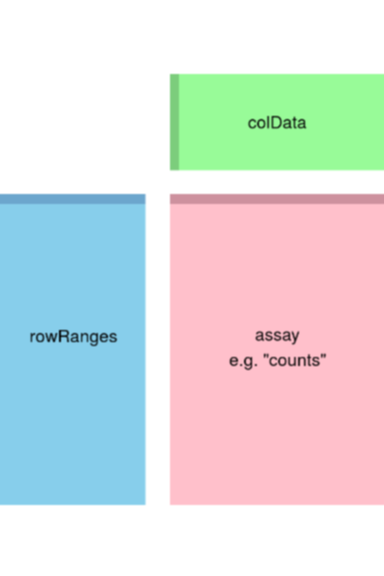

```r
colData = data.frame(condition=c("ESC","ESC","MEF","MEF","OSK_D0","OSK_D0","OSK_D1","OSK_D1","OSK_D3","OSK_D3","OSK_D5","OSK_D5","OSK_D7","OSK_D7"), row.names = colnames(counts))
# colData = data.frame(condition=gsub("(ESC|MEF|OSK_D0|OSK_D1|OSK_D3|OSK_D5|OSK_D7).*","\\1", colnames(counts)),row.names = colnames(counts), row.names = colnames(counts))
dds <- DESeqDataSetFromMatrix(countData = round(counts), colData = colData, design = ~ condition)
```

# 4 Exploratory analysis and visualization

## 4.1 Pre-filtering the dataset

```r
dds <- dds[ rowSums(counts(dds)) > 1, ]
nrow(dds)
```

```
## [1] 24023
```

## 4.2 Normalization

We use *rlog* transformation for count data that stabilize the variance across the mean ([Love, Huber, and Anders 2014](https://doi.org/10.1186/s13059-014-0550-8)).

```r
rld <- rlog(dds, blind = FALSE)
head(assay(rld), 3)
```

```
##         ESC_r1   ESC_r2    MEF_r1    MEF_r2 OSK_D0_r1 OSK_D0_r2 OSK_D1_r1
## Gnai3 9.252862 9.120151 10.072185 10.033300  9.633111  9.654527  9.921462
## Cdc45 8.650344 8.429820  7.361488  6.408245  7.329902  6.968466  7.194929
## H19   3.980216 7.120485 15.627167 14.166716 12.075260 11.464047  9.424646
##       OSK_D1_r2 OSK_D3_r1 OSK_D3_r2 OSK_D5_r1 OSK_D5_r2 OSK_D7_r1 OSK_D7_r2
## Gnai3  9.465656  8.989946  8.885033  9.821121  9.315905  9.140250  8.738998
## Cdc45  7.301066  7.641537  7.450304  6.937821  7.599029  7.841982  7.389290
## H19    8.908356  9.140444  8.050891  9.745950  9.355425  9.972744  7.918129
```

The sequencing depth of samples could be very different, one effect of normalization is to scale the sequeencing depth such that the different samples are comparable.

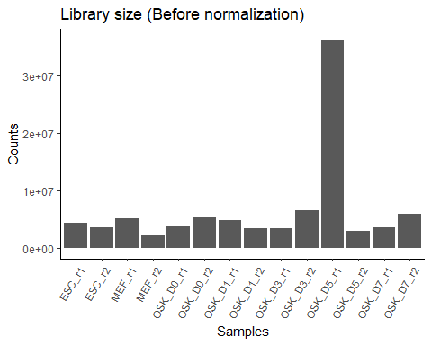

```r
libsize = data.frame(Counts=colSums(assay(dds)),Samples=colnames(dds))
ggplot(data=libsize, aes(x=Samples, y=Counts)) +
  geom_bar(stat="identity") +
  theme_classic() +
  theme(axis.text.x = element_text(angle = 60, hjust = 1)) +
  labs(title = "Library size (Before normalization)")
```

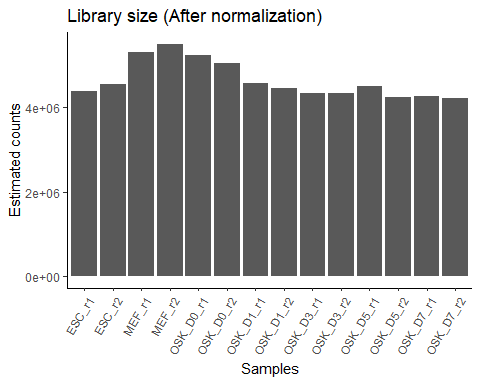

```r
libsize = data.frame(Counts=colSums(2^assay(rld)),Samples=colnames(rld))
ggplot(data=libsize, aes(x=Samples, y=Counts)) +
  geom_bar(stat="identity") +
  theme_classic() +
  theme(axis.text.x = element_text(angle = 60, hjust = 1)) +
  labs(title = "Library size (After normalization)", y = 'Estimated counts')
```

Another effect of normlization of *rlog* is to shrink the variance of low expression gene. We can see how genes with low counts (bottom left-hand corner) seem to be excessively variable on the ordinary logarithmic scale, while the rlog compress differences for the low count genes for which the data provide little information about differential expression.

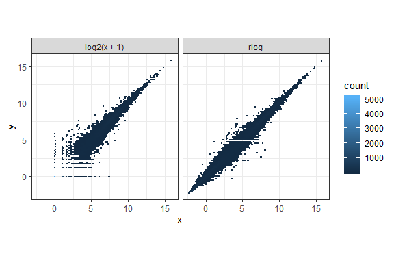

```r
dds <- estimateSizeFactors(dds)
df <- bind_rows(
  as_data_frame(log2(counts(dds, normalized=TRUE)[, 1:2]+1)) %>%
    mutate(transformation = "log2(x + 1)"),
  as_data_frame(assay(rld)[, 1:2]) %>%
    mutate(transformation = "rlog"))
colnames(df)[1:2] <- c("x", "y")
ggplot(df, aes(x = x, y = y)) + geom_hex(bins = 80) +
  coord_fixed() + facet_grid( . ~ transformation) + theme_bw()
```

## 4.3 Clustering

It is necessary to select high variable genes (HVG) to reduce the technical noise. HVG can be calculated by standard deviation of genes across samples. Here the top 500 HVGs are selected for clustering.

```r
topVarGenes = head(order(rowVars(assay(rld)), decreasing = TRUE), 500)
```

Hierarchical clustering of samples.

```r
correlationMatrix = cor(assay(rld)[topVarGenes, ])
sampleDistMatrix = 1 - correlationMatrix
rownames(correlationMatrix) = rownames(colData)
colnames(correlationMatrix) = rownames(colData)
pheatmap(correlationMatrix,
         clustering_distance_rows = as.dist(sampleDistMatrix),
         clustering_distance_cols = as.dist(sampleDistMatrix))
```

[figure not shown]

## 4.4 PCA

Principle Component Analysis (PCA) is to find the most variable direction in the data, which called principle component (PC). In general the samples can be separated in the first few PCs, help us to visualize the data in low dimensions and understand the sample similarity.  
Similarly, we use the top 500 HVG to perform PCA.

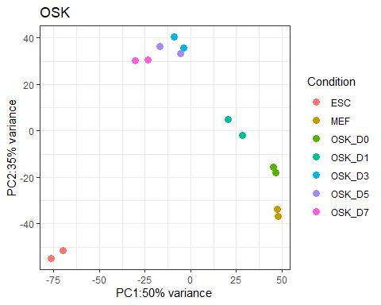

```r
pca = prcomp(t(assay(rld)[topVarGenes, ]), center = TRUE, scale. = FALSE)
xy = as.data.frame(pca$x)
expVar = round((pca$sdev)^2/sum((pca$sdev)^2) * 100)
expVar = paste0(colnames(xy), ":", expVar, "% variance")
xy$Condition = colData$condition
ggplot(xy, aes(PC1, PC2)) +
  geom_point(aes(colour=factor(Condition)), size = 3) +
  theme_bw() +
  labs(color = "Condition", title = "OSK", x = expVar[1], y = expVar[2])
```

# 5 Differential expression analysis

For illustration, we only use a subset of data to perform Differential Expressed Gene (DEG) analysis, which only contain MEF and ESC.

We will use DESeq2 ([Love, Huber, and Anders 2014](https://doi.org/10.1186/s13059-014-0550-8)) to perform differential expression analysis.

```r
sub_dds = dds[, dds$condition %in% c("ESC", "MEF")]
sub_dds$condition = droplevels(sub_dds$condition)
sub_dds
```

```
## class: DESeqDataSet
## dim: 24023 4
## metadata(1): version
## assays(1): counts
## rownames(24023): Gnai3 Cdc45 ... RP23-44D2.1 RP23-60O19.1
## rowData names(0):
## colnames(4): ESC_r1 ESC_r2 MEF_r1 MEF_r2
## colData names(2): condition sizeFactor
```

## 5.1 Running the differential expression pipeline

As we have already specified an experimental design when we created the DESeqDataSet, we can run the differential expression pipeline on the raw counts with a single call to the function `DESeq`:

```r
sub_dds = DESeq(sub_dds)
```

## 5.2 Building the results table

We contrast “ESC” to “MEF”, it means if a gene with higher expression in “ESC” than “MEF”, then `log2FoldChange > 0`.

```r
p.adj = 0.1 # The threshold of significant level
res = results(sub_dds, contrast=c("condition","ESC","MEF"), alpha = p.adj)
res[1:4, ]
```

```
## log2 fold change (MLE): condition ESC vs MEF
## Wald test p-value: condition ESC vs MEF
## DataFrame with 4 rows and 6 columns
##               baseMean    log2FoldChange             lfcSE              stat
##              <numeric>         <numeric>         <numeric>         <numeric>
## Gnai3 832.750526021415 -0.91266997541893 0.245937690168616 -3.71098051215004
## Cdc45 259.123158337333   1.6898599033498 0.425106257920455  3.97514708820401
## H19   20150.6526820735 -9.23875851653889  1.43801873071984 -6.42464407394346
## Scml2 30.8224982800368   2.5704602028707 0.920418015776579  2.79270957196762
##                     pvalue                 padj
##                  <numeric>            <numeric>
## Gnai3  0.00020645799935392 0.000865113103934722
## Cdc45 7.03357721980818e-05 0.000326905474833175
## H19     1.321784206294e-10 1.56594192103354e-09
## Scml2  0.00522685972453312   0.0149049745611349
```

# 6 Plotting results

## 6.1 Heatmap of DEG

We first sign the marker genes to each condition accroding to the `log2FoldChange` using `ifelse` function. We then pick out the top 30 significant DEG for each condition.

```r
res = as.data.frame(res[complete.cases(res), ])
res$genes = rownames(res)
res$condition = ifelse(res$log2FoldChange > 0, "ESC", "MEF")
markers = res %>% group_by(condition) %>% top_n(-30, padj)
```

Scale the gene across samples to mean = 0 and standard deviation = 1, namely z-score. Z-score often generates better visualization for gene expression heatmap.

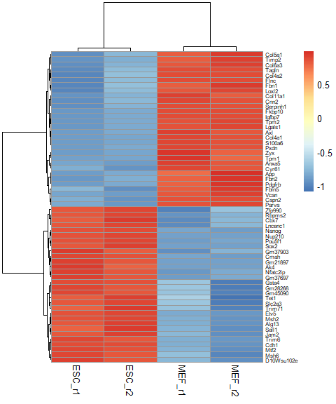

```r
norm.exp = assay(rld[markers$genes, colnames(sub_dds)])
scale.exp = t(scale(t(norm.exp)))
pheatmap(scale.exp,fontsize_row=6)
```

# 7 Enrichement analysis

## 7.1 Gene ontology

It is necessary to transform the gene `SYMBOL` to `ENTREZID` before enrichment.

```r
grlabs = split(markers$genes, markers$condition)
gcSample = lapply(grlabs, function(gr) as.numeric(bitr(gr, fromType = "SYMBOL", toType = "ENTREZID", OrgDb = "org.Mm.eg.db")$ENTREZID))
```

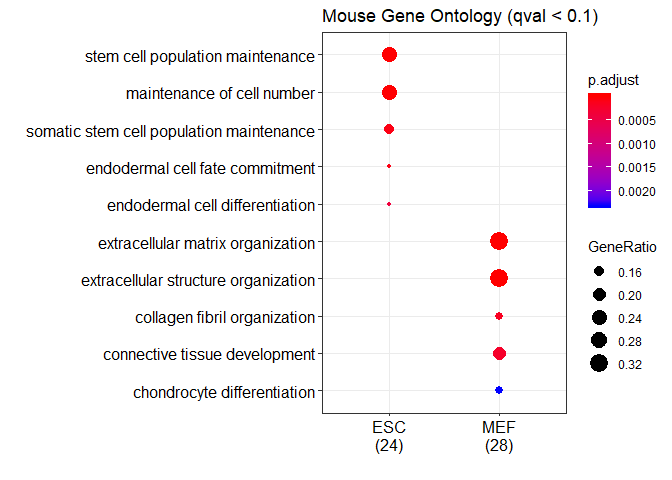

```r
# Mouse GO
pvalueCutoff = 0.1
qvalueCutoff = 0.1
xx.mus.go <- compareCluster(gcSample, OrgDb='org.Mm.eg.db', fun='enrichGO', pvalueCutoff = pvalueCutoff, qvalueCutoff = qvalueCutoff, ont = "BP", readable=T)
EnrichResGO_mm = xx.mus.go@compareClusterResult
dotplot(xx.mus.go, title = paste0("Mouse Gene Ontology (qval < ", qvalueCutoff, ")"))
```

Table of GO results.

```r
datatable(EnrichResGO_mm, filter="top", options=list(pageLength = 4))
```

|  | Cluster | ID | Description | GeneRatio | BgRatio | pvalue | p.adjust | qvalue | geneID | Count |
| --- | --- | --- | --- | --- | --- | --- | --- | --- | --- | --- |
| 1 | ESC | GO:0019827 | stem cell population maintenance | 6/24 | 165/23174 | 1.43944959528093e-08 | 6.35386977612215e-06 | 3.51462765738026e-06 | Nanog/Pou5f1/Mtf2/Sall1/Tet1/Sox2 | 6 |
| 2 | ESC | GO:0098727 | maintenance of cell number | 6/24 | 169/23174 | 1.66114242512997e-08 | 6.35386977612215e-06 | 3.51462765738026e-06 | Nanog/Pou5f1/Mtf2/Sall1/Tet1/Sox2 | 6 |
| 3 | ESC | GO:0035019 | somatic stem cell population maintenance | 4/24 | 56/23174 | 3.13397507559586e-07 | 7.99163644276944e-05 | 4.42055431715627e-05 | Nanog/Pou5f1/Sall1/Sox2 | 4 |
| 4 | ESC | GO:0001711 | endodermal cell fate commitment | 3/24 | 15/23174 | 4.40436140198401e-07 | 8.42334118129442e-05 | 4.6593507463094e-05 | Nanog/Pou5f1/Sox2 | 3 |
| 5 | ESC | GO:0035987 | endodermal cell differentiation | 3/24 | 27/23174 | 2.80837090404321e-06 | 0.000401751053280929 | 0.000222227620803486 | Nanog/Pou5f1/Sox2 | 3 |
| 6 | ESC | GO:0048863 | stem cell differentiation | 5/24 | 227/23174 | 3.15098865318376e-06 | 0.000401751053280929 | 0.000222227620803486 | Nanog/Pou5f1/Mtf2/Trim6/Sox2 | 5 |
| 7 | ESC | GO:0060795 | cell fate commitment involved in formation of primary germ layer | 3/24 | 31/23174 | 4.30405100845183e-06 | 0.000470371288780807 | 0.00026018473765378 | Nanog/Pou5f1/Sox2 | 3 |
| 8 | ESC | GO:0001706 | endoderm formation | 3/24 | 33/23174 | 5.21712995115612e-06 | 0.000498888051579304 | 0.000275958715837468 | Nanog/Pou5f1/Sox2 | 3 |
| 9 | ESC | GO:0031128 | developmental induction | 3/24 | 43/23174 | 1.17207591150401e-05 | 0.000996264524778408 | 0.00055108130575978 | Pou5f1/Sall1/Sox2 | 3 |
| 10 | ESC | GO:0001825 | blastocyst formation | 3/24 | 57/23174 | 2.75262851869285e-05 | 0.00210576081680003 | 0.00116479648896266 | Cdh1/Pou5f1/Tet1 | 3 |

[output cut: 387 more lines]

## 7.2 Gene Set Enrichment Analysis (GSEA)

Use the fold change to perform GSEA. By default, GSEA uses Reactome pathway database for enrichment - `gsePathway`. Althernately, one can use `gseGO` to perform GSEA using GO database.

```r
deg = res
gid = bitr(deg$genes, fromType = "SYMBOL", toType = "ENTREZID", OrgDb = "org.Mm.eg.db")
deg$gene_id = as.numeric(gid$ENTREZID[match(deg$genes,gid$SYMBOL)])
deg = deg[complete.cases(deg),]
geneList = structure(deg$log2FoldChange, names = deg$gene_id)
geneList = sort(geneList, decreasing = TRUE)
gsea = gsePathway(geneList, nPerm=10000,organism = "mouse",
                pvalueCutoff=0.1,
                pAdjustMethod="BH", verbose=FALSE)
```

Traslate the gene id to gene symbol.

```r
enrich_res = gsea@result
newGeneNames = sapply(enrich_res$core_enrichment, function(gs) {
  unlist(paste0(gid$SYMBOL[match(strsplit(gs, '/')[[1]], gid$ENTREZID)],collapse = '/'))
})
enrich_res$core_enrichment = newGeneNames
enrich_res = enrich_res[order(enrich_res$NES, decreasing = TRUE), ]
```

The gene sets with positive Normalized Enrichment Score (NES) are ESC enriched pathways, while gene sets with negative NES are MEF enriched pathways. Below I select two pathways for show.

```r
(enrich_res %>% top_n(5, NES))[,1:5]
```

```
##              ID                                                   Description
## 1   R-MMU-68962                     Activation of the pre-replicative complex
## 2   R-MMU-72203               Processing of Capped Intron-Containing Pre-mRNA
## 3 R-MMU-6791226 Major pathway of rRNA processing in the nucleolus and cytosol
## 4   R-MMU-72312                                               rRNA processing
## 5 R-MMU-8868773                    rRNA processing in the nucleus and cytosol
##   setSize enrichmentScore      NES
## 1      29       0.7012181 2.042293
## 2     223       0.5010721 2.030691
## 3      86       0.5640405 2.030498
## 4      86       0.5640405 2.030498
## 5      86       0.5640405 2.030498
```

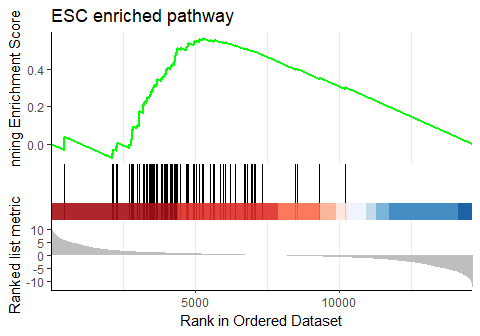

```r
gseaplot2(gsea, geneSetID = "R-MMU-72312", title='ESC enriched pathway')
```

```r
(enrich_res %>% top_n(-5, NES))[,1:5]
```

```
##              ID                                                  Description
## 1 R-MMU-1650814                  Collagen biosynthesis and modifying enzymes
## 2 R-MMU-1442490                                         Collagen degradation
## 3 R-MMU-1474290                                           Collagen formation
## 4 R-MMU-2022090 Assembly of collagen fibrils and other multimeric structures
## 5 R-MMU-1474244                            Extracellular matrix organization
##   setSize enrichmentScore       NES
## 1      56      -0.7857428 -2.405678
## 2      42      -0.8260902 -2.407585
## 3      77      -0.7727846 -2.489365
## 4      53      -0.8244494 -2.502009
## 5     205      -0.7004046 -2.529963
```

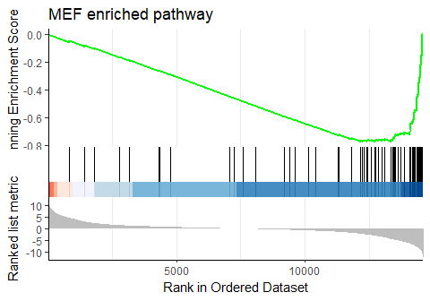

```r
gseaplot2(gsea, geneSetID = "R-MMU-1474290", title = 'MEF enriched pathway')
```

Table of GSEA results.

```r
datatable(enrich_res, filter="top", options=list(pageLength = 4))
```

|  | ID | Description | setSize | enrichmentScore | NES | pvalue | p.adjust | qvalues | rank | leading_edge | core_enrichment |
| --- | --- | --- | --- | --- | --- | --- | --- | --- | --- | --- | --- |
| R-MMU-68962 | R-MMU-68962 | Activation of the pre-replicative complex | 29 | 0.701218146224702 | 2.04229294235557 | 0.000258397932816537 | 0.00507833244822092 | 0.0038257819269363 | 3286 | tags=79%, list=22%, signal=62% | Mcm10/Orc1/Cdt1/Cdc6/Mcm3/Mcm2/Gmnn/Mcm7/Rpa3/Orc5/Pole/Mcm6/Pole4/Prim1/Pola1/Cdc45/Mcm4/Cdk2/Pola2/Pole2/Mcm8/Rpa1/Orc2 |
| R-MMU-72203 | R-MMU-72203 | Processing of Capped Intron-Containing Pre-mRNA | 223 | 0.501072119133972 | 2.03069137447253 | 0.000454132606721163 | 0.00661736084079408 | 0.00498521508129998 | 6125 | tags=76%, list=42%, signal=45% | Nup210/Elavl2/Snrpn/Nxf7/Dhx16/Cdc5l/Polr2e/Lsm3/Clp1/Lsm5/N…… |
| R-MMU-6791226 | R-MMU-6791226 | Major pathway of rRNA processing in the nucleolus and cytosol | 86 | 0.564040485676376 | 2.0304982653406 | 0.000320512820512821 | 0.00540572370745495 | 0.0040724234328608 | 5289 | tags=77%, list=36%, signal=49% | Rpp25/Utp14b/Pelp1/Exosc5/Exosc7/Ftsj3/Heatr1/Pwp2/Rpp40/Utp…… |
| R-MMU-72312 | R-MMU-72312 | rRNA processing | 86 | 0.564040485676376 | 2.0304982653406 | 0.000320512820512821 | 0.00540572370745495 | 0.0040724234328608 | 5289 | tags=77%, list=36%, signal=49% | Rpp25/Utp14b/Pelp1/Exosc5/Exosc7/Ftsj3/Heatr1/Pwp2/Rpp40/Utp…… |
| R-MMU-8868773 | R-MMU-8868773 | rRNA processing in the nucleus and cytosol | 86 | 0.564040485676376 | 2.0304982653406 | 0.000320512820512821 | 0.00540572370745495 | 0.0040724234328608 | 5289 | tags=77%, list=36%, signal=49% | Rpp25/Utp14b/Pelp1/Exosc5/Exosc7/Ftsj3/Heatr1/Pwp2/Rpp40/Utp…… |
| R-MMU-5693616 | R-MMU-5693616 | Presynaptic phase of homologous DNA pairing and strand exchange | 34 | 0.647959299041261 | 1.94880121969859 | 0.000265533722782793 | 0.00507833244822092 | 0.0038257819269363 | 3548 | tags=71%, list=24%, signal=54% | Dna2/Brca1/Bard1/Blm/Brca2/Rad51c/Rad51/Rad51b/Rpa3/Rmi2/Exo1/Rfc5/Top3a/Rad1/Hus1/Atm/Rfc4/Xrcc2/Rmi1/Rpa1/Mre11a/Atrip/Rfc2/Brip1 |
| R-MMU-69206 | R-MMU-69206 | G1/S Transition | 51 | 0.591515067383881 | 1.94707944767044 | 0.000277546489036914 | 0.00519974850889565 | 0.00391725119865204 | 3634 | tags=57%, list=25%, signal=43% | Mcm10/Orc1/Cdt1/Cdc6/Mcm3/Mcm2/Gmnn/Mcm7/Rpa3/Orc5/Pole/Wee1/Mcm6/Pole4/Prim1/Pola1/Cdc45/Mcm4/Cdk2/Pola2/Pole2/Cdc25a/Mcm8/Rpa1/Orc2/Skp1a/Ccne1/Uba52/Dbf4 |
| R-MMU-5693579 | R-MMU-5693579 | Homologous DNA Pairing and Strand Exchange | 37 | 0.630932720956471 | 1.94279707940229 | 0.000265041081367612 | 0.00507833244822092 | 0.0038257819269363 | 3548 | tags=68%, list=24%, signal=51% | Dna2/Brca1/Bard1/Blm/Brca2/Rad51c/Rad51/Rad51b/Rpa3/Rmi2/Exo1/Rfc5/Top3a/Rad1/Hus1/Atm/Rfc4/Rad51ap1/Xrcc2/Rmi1/Rpa1/Mre11a/Atrip/Rfc2/Brip1 |
| R-MMU-72163 | R-MMU-72163 | mRNA Splicing - Major Pathway | 168 | 0.493171576237755 | 1.94062417468983 | 0.000395256916996047 | 0.00604743083003953 | 0.00455585604327023 | 6361 | tags=79%, list=44%, signal=45% | Elavl2/Snrpn/Dhx16/Cdc5l/Polr2e/Lsm3/Clp1/Lsm5/Ppil1/Hspa8/L…… |
| R-MMU-8953854 | R-MMU-8953854 | Metabolism of RNA | 411 | 0.44872531522271 | 1.92996806056137 | 0.000677966101694915 | 0.00864406779661017 | 0.00651204281891169 | 6125 | tags=73%, list=42%, signal=43% | Nup210/Rpp25/Apobec2/Elavl2/Zfp473/Gemin4/Snrpn/Nxf7/Dcp2/Ap…… |

[output cut: 183 more lines]

# 8 Exporting results

```r
deg = res %>% filter(padj < 0.01) %>% arrange(log2FoldChange)
write.csv(deg, "osk_deg.csv")
```

# 9 Session information